# Assignment 1 FoML

Zach Ours

2026-09-10

For this assignment, I will use NFL play-by-play data from the nflverse project.I chose this dataset because I am interested in sports analytics and wanted to explore the relationship between different statistics from NFL plays.

```r
library(nflreadr)
library(dplyr)
# Source: nflverse NFL play-by-play data
nfl_data <- load_pbp(2025)
```

```r
head(nfl_data)
```

```
## ── nflverse play by play data ──────────────────────────────────────────────────
```

```
## ℹ Data updated: 2026-08-13 08:26:02 EDT
```

```
## # A tibble: 6 × 372
##   play_id game_id      old_game_id home_team away_team season_type  week posteam
##     <dbl> <chr>        <chr>       <chr>     <chr>     <chr>       <int> <chr>
## 1       1 2025_01_ARI… 2025090705  NO        ARI       REG             1 <NA>
## 2      40 2025_01_ARI… 2025090705  NO        ARI       REG             1 ARI
## 3      63 2025_01_ARI… 2025090705  NO        ARI       REG             1 ARI
## 4      85 2025_01_ARI… 2025090705  NO        ARI       REG             1 ARI
## 5     115 2025_01_ARI… 2025090705  NO        ARI       REG             1 ARI
## 6     135 2025_01_ARI… 2025090705  NO        ARI       REG             1 ARI
## # ℹ 364 more variables: posteam_type <chr>, defteam <chr>, side_of_field <chr>,
## #   yardline_100 <dbl>, game_date <chr>, quarter_seconds_remaining <dbl>,
## #   half_seconds_remaining <dbl>, game_seconds_remaining <dbl>,
## #   game_half <chr>, quarter_end <dbl>, drive <dbl>, sp <dbl>, qtr <dbl>,
## #   down <dbl>, goal_to_go <dbl>, time <chr>, yrdln <chr>, ydstogo <dbl>,
## #   ydsnet <dbl>, desc <chr>, play_type <chr>, yards_gained <dbl>,
## #   shotgun <dbl>, no_huddle <dbl>, qb_dropback <dbl>, qb_kneel <dbl>, …
```

```r
dim(nfl_data)
```

```
## [1] 48771   372
```

```r
nfl_small <- nfl_data %>%
  select(
    posteam,
    defteam,
    play_type,
    yards_gained,
    air_yards,
    yards_after_catch,
    down
  )
```

```r
head(nfl_small)
```

```
## ── nflverse play by play data ──────────────────────────────────────────────────
```

```
## ℹ Data updated: 2026-08-13 08:26:02 EDT
```

```
## # A tibble: 6 × 7
##   posteam defteam play_type yards_gained air_yards yards_after_catch  down
##   <chr>   <chr>   <chr>            <dbl>     <dbl>             <dbl> <dbl>
## 1 <NA>    <NA>    <NA>                NA        NA                NA    NA
## 2 ARI     NO      kickoff              0        NA                NA    NA
## 3 ARI     NO      run                  3        NA                NA     1
## 4 ARI     NO      pass                11         3                 8     2
## 5 ARI     NO      pass               -11        NA                NA     1
## 6 ARI     NO      run                 -2        NA                NA     2
```

### Quantitative Variables

```r
summary(nfl_small$yards_gained)
```

```
##    Min. 1st Qu.  Median    Mean 3rd Qu.    Max.     NAs
## -34.000   0.000   1.000   3.945   6.000  93.000    1511
```

```r
summary(nfl_small$air_yards)
```

```
##    Min. 1st Qu.  Median    Mean 3rd Qu.    Max.     NAs
## -19.000   1.000   5.000   7.815  13.000  64.000   30402
```

### Categorical Variables

```r
table(nfl_small$play_type)
```

```
##
## extra_point  field_goal     kickoff     no_play        pass        punt
##        1330        1140        2927        4723       19737        2042
##    qb_kneel    qb_spike         run
##         452          80       14895
```

```r
table(nfl_small$posteam)
```

```
##
##  ARI  ATL  BAL  BUF  CAR  CHI  CIN  CLE  DAL  DEN  DET   GB  HOU  IND  JAX   KC
## 1416 1389 1303 1559 1401 1637 1405 1371 1488 1587 1394 1408 1612 1340 1512 1379
##   LA  LAC   LV  MIA  MIN   NE   NO  NYG  NYJ  PHI  PIT  SEA   SF   TB  TEN  WAS
## 1674 1500 1263 1255 1271 1694 1399 1434 1336 1429 1382 1581 1527 1420 1347 1329
```

## Variable Transformation

A new variable called `big_play` was created. A play is classified as a big play if it gained at least 20 yards.

```r
nfl_small <- nfl_small %>%
  mutate(
    big_play = ifelse(yards_gained >= 20, "Yes", "No")
  )
```

```r
table(nfl_small$big_play)
```

```
##
##    No   Yes
## 45272  1988
```

## Histogram

The following histogram shows the distribution of yards gained per play. Most plays fall within a relatively small range of yards gained, while larger gains occur less frequently.

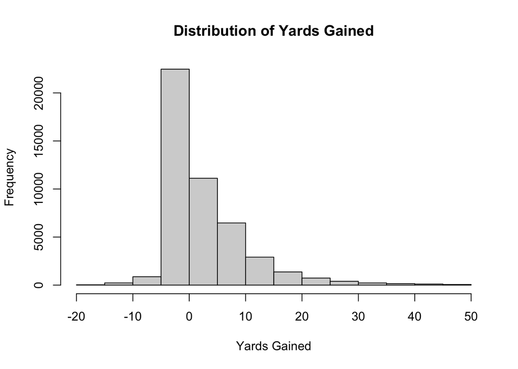

```r
hist(
  nfl_small$yards_gained[nfl_small$yards_gained >= -20 &
                           nfl_small$yards_gained <= 50],
  main = "Distribution of Yards Gained",
  xlab = "Yards Gained"
)
```

## Scatterplot

The following scatterplot compares air yards to total yards gained.

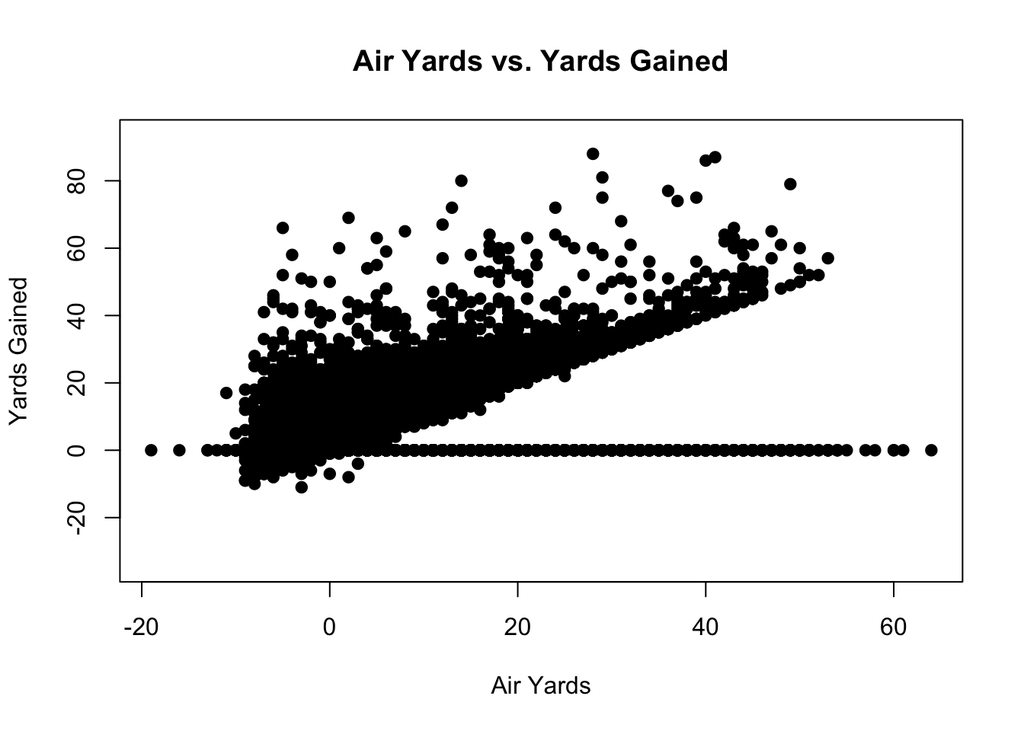

```r
plot(
  nfl_small$air_yards,
  nfl_small$yards_gained,
  main = "Air Yards vs. Yards Gained",
  xlab = "Air Yards",
  ylab = "Yards Gained",
  pch = 19
)
```

The scatterplot shows a general positive relationship between air yards and total yards gained. Passes thrown farther downfield often result in more total yards, although there is considerable variation between individual plays.

## Conclusion

In this assignment, I used R to analyze NFL play-by-play data from the 2025 season. I selected quantitative and categorical variables, calculated descriptive statistics, transformed the yards gained variable to identify big plays, and created a histogram and scatterplot to visualize the data.